Titre: **Projet R Data Viz**

Nom: Nouran GHALIOUNJI

Pacours: M1 BIDADI

# Introduction

Nous avons une basé de données sous forme de fichier Excel qui inclut les variables suivantes:

- Identifier (RIC) : identifiant RIC de l’entreprise
- Company Name : Nom de l’entreprise
- ISIN : code ISIN de l’entreprise
- COUNTRY OF DOMICIL: code du pays de l’entreprise

**Variables environnementales :**

- Environment Pillar Score: mesure de la performance environnementale de l’entreprise. Il s’agit de la composante E de la norme ESG
- Carbon Intensity per Energy Produced : Mesure relative aux émissions de CO2

  **Variables économiques et commerciales**
- EMPLOYEES (EMP) : nombre d’employés par entreprise comme mesure de la taille de l’entreprise
- OPERATING PROFIT MARGIN (MARGIN) : profit opérationnel de l’entreprise
- NET SALES OR REVENUES (SALES) : les revenus commerciaux nets

  **Variables financières**
- Market Cap (MCAP): capitalisation boursière de l’entreprise
- RETURN ON INVESTED CAPITAL (RCAP): le rendement du capital investi
- Plusieurs Variables PRIX : o 1-day Price PCT Change o 5-day Price PCT Change o 4-week Price PCT Change o 13-week Price PCT Change o 26-week Price PCT Change o YTD Price PCT Change o 52-week Price PCT Change o Price 52 Week High

  **Variables de gouvernance**
- CSR Sustainability Committee (CSR) : la mise en place d’un comité de soutenabilité CSR ou pas (Y si oui et N sinon)
- Value - Board Structure/Independent Board Members (Board): le pourcentage des members indépendants dans le board

Le but de notre travail est de saisir l’impact des variables économiques, financières, et de gouvernance des entreprises listées dans notre base de données sur notre variable environnementale: le score environnemental.

Tout au long de notre travail on va tenter d’analyser nos données, et de prendre des décisions dont le but ultime est de construire le modèle le moins biaisé possible.

On commence tout d’abord pour importer dans notre environnement les libraries nécessaires pour le travail

```r
library('readxl')
library('dplyr')
```

```r
library('dplyr')
library('ggplot2')
#Elle nous permettera de lire les résumés summary de manière plus lisible
library('pander')
#On désactive les altertes
options(warn=-1)
```

Partie 1:

On importe tout d’abord le jeu de données qui est sous forme de fichier Excel qu’on stockera dans le dataframe ‘eurostoxx’

```r
eurostoxx<-read_excel("C:/Users/Visiteur/Downloads/Projet R/variables_EuroStoxx600.xlsx")
View(eurostoxx)
```

```r
summary(eurostoxx)
```

```
##       ...1       Identifier (RIC)   Company Name       Market Cap\r\n(Σ=Avg)
##  Min.   :  1.0   Length:600         Length:600         Min.   :1.480e+09
##  1st Qu.:150.8   Class :character   Class :character   1st Qu.:5.548e+09
##  Median :300.5   Mode  :character   Mode  :character   Median :1.386e+10
##  Mean   :300.5                                         Mean   :4.050e+10
##  3rd Qu.:450.2                                         3rd Qu.:3.639e+10
##  Max.   :600.0                                         Max.   :1.322e+12
##
##  1-day Price PCT Change\r\n(Σ=Avg) 5-day Price PCT Change\r\n(Σ=Avg)
##  Min.   :-0.051041                 Min.   :-0.179707
##  1st Qu.: 0.009273                 1st Qu.:-0.015761
##  Median : 0.020902                 Median : 0.007905
##  Mean   : 0.021824                 Mean   : 0.008012
##  3rd Qu.: 0.031834                 3rd Qu.: 0.031576
##  Max.   : 0.127511                 Max.   : 0.319608
##
##  4-week Price PCT Change\r\n(Σ=Avg) 13-week Price PCT Change\r\n(Σ=Avg)
##  Min.   :-0.319034                  Min.   :-0.56503
##  1st Qu.:-0.111113                  1st Qu.:-0.19708
##  Median :-0.054442                  Median :-0.11217
##  Mean   :-0.054558                  Mean   :-0.09933
##  3rd Qu.:-0.001157                  3rd Qu.:-0.00910
##  Max.   : 0.307981                  Max.   : 0.89705
##
##  26-week Price PCT Change\r\n(Σ=Avg) YTD Price PCT Change\r\n(Σ=Avg)
##  Min.   :-0.75714                    Min.   :-0.70571
##  1st Qu.:-0.28356                    1st Qu.:-0.26691
##  Median :-0.15780                    Median :-0.15225
##  Mean   :-0.14140                    Mean   :-0.13650
##  3rd Qu.:-0.02425                    3rd Qu.:-0.01928
##  Max.   : 1.08930                    Max.   : 1.21406
##  NA's   :1
##  52-week Price PCT Change\r\n(Σ=Avg) Price 52 Week High\r\n(Σ=Avg)
##  Min.   :-0.73172                    Min.   :     0.51
##  1st Qu.:-0.19871                    1st Qu.:    51.73
##  Median :-0.05979                    Median :   161.43
##  Mean   :-0.04575                    Mean   :  1000.63
##  3rd Qu.: 0.08607                    3rd Qu.:   580.15
##  Max.   : 1.94601                    Max.   :123800.00
##  NA's   :8
```

[output cut: 49 more lines]

```
##  Length:600
##  Class :character
##  Mode  :character
##
##
##
##
##  Carbon Intensity per Energy Produced
##  Length:600
##  Class :character
##  Mode  :character
##
##
##
##
```

# **PARTIE 1: Réponse question 1**

Lorsqu’on execute la fonction str pour voir la structure de la colonne carbonne intensity per energy producted, on remarque que les ‘NA’ qui sont les valeurs manquantes sont stockés tel que des chaînes de caractère. Dans cette étude on doit s’en tenir à la première variable qui est Environement Pillar Score (EPS) car la variable Carbon Intensity per Energy produced est manquante pour la plupart des observations

```r
str(eurostoxx$`Carbon Intensity per Energy Produced`)
```

```
##  chr [1:600] "NA" "NA" "NA" "NA" "NA" "NA" "NA" "NA" "NA" "NA" "NA" "NA" ...
```

On vérifie une seconde fois avec la fonction is NA et on voit bien ici que R ne reconnaît pas les chaines de caractères ‘NA’ tel que des valeurs manquantes.

```r
is.na(eurostoxx$'Carbon Intensity per Energy Produced')
```

```
##   [1] FALSE FALSE FALSE FALSE FALSE FALSE FALSE FALSE FALSE FALSE FALSE FALSE
##  [13] FALSE FALSE FALSE FALSE FALSE FALSE FALSE FALSE FALSE FALSE FALSE FALSE
##  [25] FALSE FALSE FALSE FALSE FALSE FALSE FALSE FALSE FALSE FALSE FALSE FALSE
##  [37] FALSE FALSE FALSE FALSE FALSE FALSE FALSE FALSE FALSE FALSE FALSE FALSE
##  [49] FALSE FALSE FALSE FALSE FALSE FALSE FALSE FALSE FALSE FALSE FALSE FALSE
##  [61] FALSE FALSE FALSE FALSE FALSE FALSE FALSE FALSE FALSE FALSE FALSE FALSE
##  [73] FALSE FALSE FALSE FALSE FALSE FALSE FALSE FALSE FALSE FALSE FALSE FALSE
##  [85] FALSE FALSE FALSE FALSE FALSE FALSE FALSE FALSE FALSE FALSE FALSE FALSE
##  [97] FALSE FALSE FALSE FALSE FALSE FALSE FALSE FALSE FALSE FALSE FALSE FALSE
## [109] FALSE FALSE FALSE FALSE FALSE FALSE FALSE FALSE FALSE FALSE FALSE FALSE
## [121] FALSE FALSE FALSE FALSE FALSE FALSE FALSE FALSE FALSE FALSE FALSE FALSE
## [133] FALSE FALSE FALSE FALSE FALSE FALSE FALSE FALSE FALSE FALSE FALSE FALSE
## [145] FALSE FALSE FALSE FALSE FALSE FALSE FALSE FALSE FALSE FALSE FALSE FALSE
## [157] FALSE FALSE FALSE FALSE FALSE FALSE FALSE FALSE FALSE FALSE FALSE FALSE
## [169] FALSE FALSE FALSE FALSE FALSE FALSE FALSE FALSE FALSE FALSE FALSE FALSE
```

[output cut: 35 more lines]

On utilise la fonction na.if pour remplacer les chaînes de caractère ‘NA’ en tant que NA pour que R puisse les traiter comme tel.

```r
eurostoxx$'Carbon Intensity per Energy Produced'[eurostoxx$'Carbon Intensity per Energy Produced' == 'NA'] <- NA
```

On vérfie de nouveau avec la fonction is.na si l’oppération a fonctionné et cette fois-ci on obtient bien la boolean TRUE lorsqu’on lance la ligne de code.

```r
is.na(eurostoxx$'Carbon Intensity per Energy Produced')
```

```
##   [1]  TRUE  TRUE  TRUE  TRUE  TRUE  TRUE  TRUE  TRUE  TRUE  TRUE  TRUE  TRUE
##  [13]  TRUE  TRUE  TRUE  TRUE  TRUE  TRUE  TRUE  TRUE  TRUE  TRUE  TRUE  TRUE
##  [25]  TRUE  TRUE  TRUE  TRUE  TRUE  TRUE  TRUE  TRUE  TRUE  TRUE  TRUE  TRUE
##  [37]  TRUE  TRUE  TRUE  TRUE  TRUE  TRUE  TRUE  TRUE  TRUE  TRUE  TRUE  TRUE
##  [49]  TRUE  TRUE  TRUE  TRUE  TRUE  TRUE  TRUE  TRUE  TRUE  TRUE FALSE  TRUE
##  [61]  TRUE  TRUE  TRUE  TRUE  TRUE  TRUE  TRUE  TRUE  TRUE  TRUE  TRUE  TRUE
##  [73]  TRUE  TRUE  TRUE  TRUE  TRUE  TRUE  TRUE  TRUE  TRUE  TRUE  TRUE  TRUE
##  [85]  TRUE  TRUE  TRUE  TRUE  TRUE  TRUE  TRUE  TRUE  TRUE  TRUE  TRUE  TRUE
##  [97]  TRUE  TRUE  TRUE  TRUE  TRUE  TRUE  TRUE  TRUE  TRUE  TRUE  TRUE  TRUE
## [109]  TRUE  TRUE  TRUE  TRUE  TRUE  TRUE  TRUE  TRUE  TRUE  TRUE  TRUE  TRUE
## [121]  TRUE  TRUE  TRUE  TRUE  TRUE  TRUE  TRUE  TRUE  TRUE  TRUE  TRUE  TRUE
## [133]  TRUE  TRUE  TRUE  TRUE  TRUE  TRUE  TRUE  TRUE  TRUE  TRUE  TRUE  TRUE
## [145]  TRUE  TRUE  TRUE  TRUE  TRUE  TRUE  TRUE  TRUE  TRUE  TRUE  TRUE  TRUE
## [157]  TRUE  TRUE  TRUE  TRUE  TRUE  TRUE  TRUE  TRUE  TRUE  TRUE  TRUE  TRUE
## [169]  TRUE  TRUE  TRUE  TRUE  TRUE  TRUE  TRUE  TRUE  TRUE  TRUE  TRUE  TRUE
```

[output cut: 35 more lines]

On effectue la même opération sur tout le data frame pour ne pas avoir a rencontré le même problème de nouveau en utilisant la fonction replace.

```r
eurostoxx <-  replace(eurostoxx, eurostoxx=='NA', NA)
```

# PARTIE 2: Analyse en composante principale

L’analyse en composante principale (ACP) est une technique de réduction de dimensionalité qui permet de visualiser des données et d’identifier les relations entre les différentes variables quantitatives. D’autres méthodes de réduction de dimensions existent aussi pour les données qui sont de nature qualitatives tel que l’analyse des correspondances. Dans notre cas ici, nous avons 8 variables financières et on souhaite pouvoir observer la relation entre ces variables. Typiquement, lorsqu’on a deux ou trois variables, il est assez facile de les représenter visuellement et de saisir la ou les relations qui existent entre elles. Mais dans le cas où nous avons 8 variables comme ici, il est difficile de les visualiser et de saisir la complexité de toutes les relations qui peuvent exister entre les variables. Pour cela, nous avons recours à l’ACP afin d’identifier les relations qui existent entre les différentes variables financières sur le plan multivarié et ponctuellement d’analyser et les ressemblances et les oppositions entre les différentes observations sur notre jeu de données.

De plus, il est utile de rappeler que le but ultime de notre analyse est de saisir l’impact des différentes variables financières, économiques, et de gouvernance sur la performance environnementale des entreprises en effectuant une régression linéaire. L’ajout de nombreuses variables dans une régression peut finir par devenir pénalisant dans notre analyse dans le sens ou il introduirait beaucoup trop de degrés de liberté dans la régression et potentiellement d’autres biais. Synthétiser les nombreuses variables financières que nous obtiendrons grâce à l’ACP nous permettra de tenir compte de l’aspect financier en une seule variable que l’on nommera ‘Fi’ et qu’on pourra directement introduire dans la régression.

Pour effectuer l’analyse en composante principale sur les variables financières, tout d’abord on va reconstruire une data frame à partir des variables financières d’eurostoxx.

```r
print(colnames(eurostoxx))
```

```
##  [1] "...1"
##  [2] "Identifier (RIC)"
##  [3] "Company Name"
##  [4] "Market Cap\r\n(Σ=Avg)"
##  [5] "1-day Price PCT Change\r\n(Σ=Avg)"
##  [6] "5-day Price PCT Change\r\n(Σ=Avg)"
##  [7] "4-week Price PCT Change\r\n(Σ=Avg)"
##  [8] "13-week Price PCT Change\r\n(Σ=Avg)"
##  [9] "26-week Price PCT Change\r\n(Σ=Avg)"
## [10] "YTD Price PCT Change\r\n(Σ=Avg)"
## [11] "52-week Price PCT Change\r\n(Σ=Avg)"
## [12] "Price 52 Week High\r\n(Σ=Avg)"
## [13] "Price 52 Week Low\r\n(Σ=Avg)"
## [14] "Average Daily Volume - 10 Days\r\n(Σ=Avg)"
## [15] "Average Daily Volume - 3 Months\r\n(Σ=Avg)"
## [16] "ISIN"
## [17] "COUNTRY OF DOMICIL"
## [18] "EMPLOYEES"
## [19] "OPERATING PROFIT MARGIN"
## [20] "OPERATING INCOME"
## [21] "NET SALES OR REVENUES"
## [22] "Environment Pillar Score"
## [23] "CSR Sustainability Committee"
## [24] "RETURN ON INVESTED CAPITAL"
## [25] "Value - Board Structure/Independent Board Members"
## [26] "Value - Board Structure/Strictly Independent Board Members"
## [27] "Carbon Intensity per Energy Produced"
```

```r
eurostoxx_acp <- eurostoxx[ ,c("Company Name" , "1-day Price PCT Change\r\n(Σ=Avg)" , "5-day Price PCT Change\r\n(Σ=Avg)", "4-week Price PCT Change\r\n(Σ=Avg)", "13-week Price PCT Change\r\n(Σ=Avg)","26-week Price PCT Change\r\n(Σ=Avg)","YTD Price PCT Change\r\n(Σ=Avg)","52-week Price PCT Change\r\n(Σ=Avg)", "Price 52 Week High\r\n(Σ=Avg)")]
```

Comme les noms des colonnes sont très compliqués, nous allons renommer chacune des colonnes sélectionnées afin d’avoir des noms qui soient plus simples.

```r
colnames(eurostoxx_acp) <- c("Company Name","1-day Price PCT Change", "5-day Price PCT Change
", "4-week Price PCT Change", "13-week Price PCT Change", "26-week Price PCT Change", "YTD Price PCT Change", "52-week Price PCT Change", "Price 52 Week High")
```

On commence en suite par charger les packages dont on a besoin pour effectuer l’ACP

```r
library('FactoMineR')
library('corrplot')
library('factoextra')
```

On remarque que pour la colonne ‘26 Week price change’ nous avons une valeur manquante. Pour exécuter notre ACP correctement, on ne doit pas avoir de valeur manquante et on va donc la remplacer par la valeur de la médiane sur cette colonne.

```r
pander(summary(eurostoxx_acp))
```

Table continues below

| Company Name | 1-day Price PCT Change | 5-day Price PCT Change |
| --- | --- | --- |
| Length:600 | Min. :-0.051041 | Min. :-0.179707 |
| Class :character | 1st Qu.: 0.009273 | 1st Qu.:-0.015761 |
| Mode :character | Median : 0.020902 | Median : 0.007905 |
| NA | Mean : 0.021824 | Mean : 0.008012 |
| NA | 3rd Qu.: 0.031834 | 3rd Qu.: 0.031576 |
| NA | Max. : 0.127511 | Max. : 0.319608 |
| NA | NA | NA |

Table continues below

| 4-week Price PCT Change | 13-week Price PCT Change | 26-week Price PCT Change |
| --- | --- | --- |
| Min. :-0.319034 | Min. :-0.56503 | Min. :-0.75714 |
| 1st Qu.:-0.111113 | 1st Qu.:-0.19708 | 1st Qu.:-0.28356 |
| Median :-0.054442 | Median :-0.11217 | Median :-0.15780 |
| Mean :-0.054558 | Mean :-0.09933 | Mean :-0.14140 |
| 3rd Qu.:-0.001157 | 3rd Qu.:-0.00910 | 3rd Qu.:-0.02425 |
| Max. : 0.307981 | Max. : 0.89705 | Max. : 1.08930 |
| NA | NA | NA’s :1 |

| YTD Price PCT Change | 52-week Price PCT Change | Price 52 Week High |
| --- | --- | --- |
| Min. :-0.70571 | Min. :-0.73172 | Min. : 0.51 |
| 1st Qu.:-0.26691 | 1st Qu.:-0.19871 | 1st Qu.: 51.73 |
| Median :-0.15225 | Median :-0.05979 | Median : 161.43 |
| Mean :-0.13650 | Mean :-0.04575 | Mean : 1000.63 |
| 3rd Qu.:-0.01928 | 3rd Qu.: 0.08607 | 3rd Qu.: 580.15 |
| Max. : 1.21406 | Max. : 1.94601 | Max. :123800.00 |
| NA | NA’s :8 | NA |

```r
eurostoxx_acp$'26-week Price PCT Change'[is.na(eurostoxx_acp$'26-week Price PCT Change')] <- median(eurostoxx_acp$'26-week Price PCT Change', na.rm = TRUE)
eurostoxx_acp$'52-week Price PCT Change'[is.na(eurostoxx_acp$'52-week Price PCT Change')]<- median(eurostoxx_acp$'52-week Price PCT Change', na.rm = TRUE)
pander(summary(eurostoxx_acp))
```

Table continues below

| Company Name | 1-day Price PCT Change | 5-day Price PCT Change |
| --- | --- | --- |
| Length:600 | Min. :-0.051041 | Min. :-0.179707 |
| Class :character | 1st Qu.: 0.009273 | 1st Qu.:-0.015761 |
| Mode :character | Median : 0.020902 | Median : 0.007905 |
| NA | Mean : 0.021824 | Mean : 0.008012 |
| NA | 3rd Qu.: 0.031834 | 3rd Qu.: 0.031576 |
| NA | Max. : 0.127511 | Max. : 0.319608 |

Table continues below

| 4-week Price PCT Change | 13-week Price PCT Change | 26-week Price PCT Change |
| --- | --- | --- |
| Min. :-0.319034 | Min. :-0.56503 | Min. :-0.75714 |
| 1st Qu.:-0.111113 | 1st Qu.:-0.19708 | 1st Qu.:-0.28337 |
| Median :-0.054442 | Median :-0.11217 | Median :-0.15780 |
| Mean :-0.054558 | Mean :-0.09933 | Mean :-0.14143 |
| 3rd Qu.:-0.001157 | 3rd Qu.:-0.00910 | 3rd Qu.:-0.02444 |
| Max. : 0.307981 | Max. : 0.89705 | Max. : 1.08930 |

| YTD Price PCT Change | 52-week Price PCT Change | Price 52 Week High |
| --- | --- | --- |
| Min. :-0.70571 | Min. :-0.73172 | Min. : 0.51 |
| 1st Qu.:-0.26691 | 1st Qu.:-0.19670 | 1st Qu.: 51.73 |
| Median :-0.15225 | Median :-0.05979 | Median : 161.43 |
| Mean :-0.13650 | Mean :-0.04594 | Mean : 1000.63 |
| 3rd Qu.:-0.01928 | 3rd Qu.: 0.08338 | 3rd Qu.: 580.15 |
| Max. : 1.21406 | Max. : 1.94601 | Max. :123800.00 |

Avant d’effectuer l’ACP, on fait une matrice des corrélations pour tenter de voir les relations qui existent entre les différentes variables. La couleur bleu foncée signifie qu’il existe une forte corrélation positive entre deux variables et la couleur rouge vive fait référence à une corrélation négative forte entre deux variables. Ici il ne semble y avoir de corrélation négative forte, mais par contre certaines variables sont corrélées fortement de façon positive entre elles comme ‘52 week price change’, ‘13 week price percerntage change’, ‘26 week price percentage change’, et ‘YTD price percentage change’. Cela semble indiqué qu’il existe une forte corrélation entre les changements de prix sur le long terme et c’est quelque chose que l’on pourra investiguer davantage après avoir effectué notre ACP.

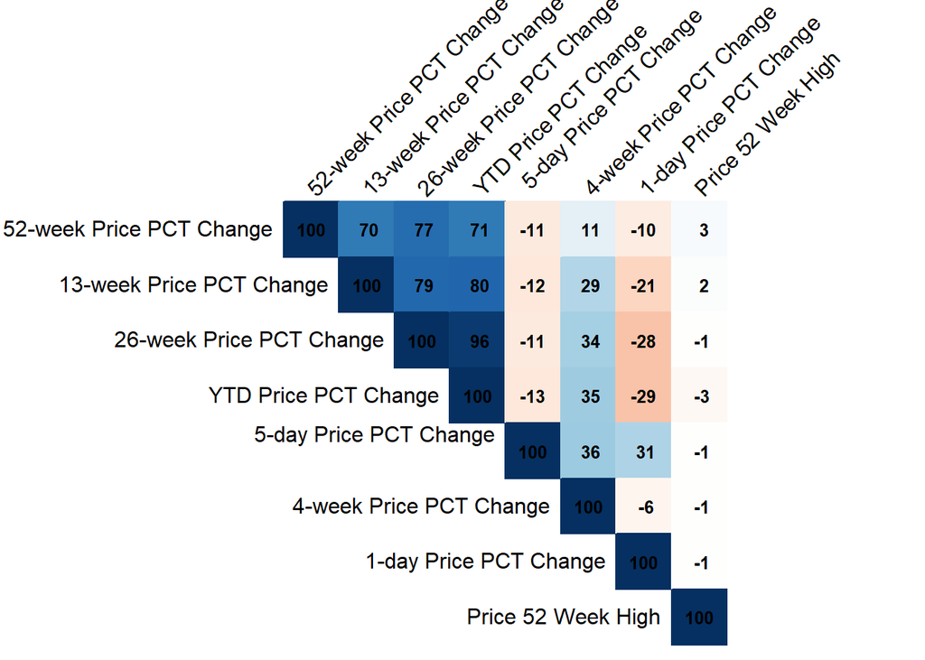

```r
matrice_correlation <- cor(eurostoxx_acp %>% select_if(is.numeric), use = "complete.obs")


corrplot(matrice_correlation, method="color", type='upper', order= "hclust",
         tl.col= "black", tl.srt= 45,
        addCoef.col = 'black',
        cl.pos= "n",
        cl.cex= 1.2,
        addCoefasPercent = TRUE,
        number.cex= 0.8)
```

Nous effectuons notre ACP et obtenons ainsi les résultats suivants:

- Le premier tableau renvoie la variation expliquée par chaque composante principale. Dans notre cas nous avons 8 composantes puisque nous avons 8 variables entre lesquelles nous cherchons à expliquer le lien.
- Le graphique des individus: Ce graphique renvoie la représentation des individus en fonction du premier et et du deuxième axe obtenus par l’analyse en composante principale. Plus les individus sont proches l’un de l’autre dans l’espace, plus ils ont de similitude. Dans notre cas, on remarque que l’entreprise ‘Swedish Match AB’ (individu 449 sur le graphique) se distingue fortement des autres individus.
- Le graphique des variables: Ce graphique renvoie la représentation des variables en fonction de la première et de la deuxième dimension. Plus des variables sont proches dans l’espace, plus sont corrélées entre elles.

### Interprétation des résultats obtenus

Les variations expliquées par l’analyse: La première dimension explique plus de 44% de la variation dans les variables, la deuxième dimension n’en explique que 18% et puis la 3eme en explique 12% . Ainsi, les 3 premières dimensions de notre ACP expliquent déjà 75% de la variation qui existe entre nos variables financières.

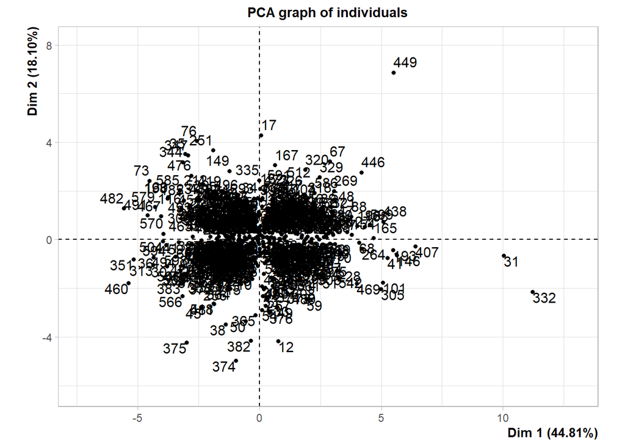

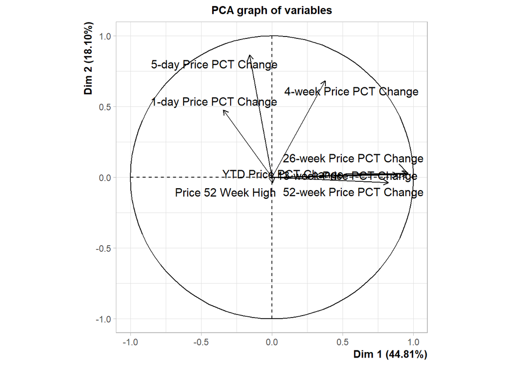

```r
rownames(eurostoxx_acp) <- eurostoxx_acp$`Company Name`
acp_eurostoxx <- PCA((eurostoxx_acp %>% select_if(is.numeric)), scale.unit= T, ncp=length(1:9), graph= T)
```

```r
print(summary(acp_eurostoxx))
```

```
##
## Call:
## PCA(X = (eurostoxx_acp %>% select_if(is.numeric)), scale.unit = T,
##      ncp = length(1:9), graph = T)
##
##
## Eigenvalues
##                        Dim.1   Dim.2   Dim.3   Dim.4   Dim.5   Dim.6   Dim.7
## Variance               3.585   1.448   1.004   0.930   0.481   0.265   0.248
## % of var.             44.809  18.105  12.556  11.627   6.012   3.318   3.102
## Cumulative % of var.  44.809  62.913  75.469  87.096  93.108  96.426  99.528
##                        Dim.8
## Variance               0.038
## % of var.              0.472
## Cumulative % of var. 100.000
##
## Individuals (the 10 first)
##                              Dist    Dim.1    ctr   cos2    Dim.2    ctr   cos2
## 1                        |  2.022 | -1.304  0.079  0.416 | -0.662  0.050  0.107
## 2                        |  1.182 | -0.093  0.000  0.006 |  0.115  0.002  0.009
## 3                        |  1.955 |  1.486  0.103  0.578 |  1.017  0.119  0.270
## 4                        |  2.268 | -1.729  0.139  0.581 |  0.719  0.060  0.101
## 5                        |  2.859 | -1.760  0.144  0.379 |  1.749  0.352  0.374
## 6                        |  2.672 | -2.097  0.204  0.616 |  0.557  0.036  0.044
## 7                        |  2.570 |  1.948  0.176  0.575 |  1.598  0.294  0.387
## 8                        |  1.995 | -0.463  0.010  0.054 | -0.540  0.034  0.073
## 9                        |  2.035 | -0.364  0.006  0.032 |  0.682  0.054  0.112
## 10                       |  2.057 | -0.302  0.004  0.022 | -1.620  0.302  0.620
##                             Dim.3    ctr   cos2
## 1                        | -0.219  0.008  0.012 |
## 2                        | -0.239  0.009  0.041 |
## 3                        | -0.179  0.005  0.008 |
## 4                        |  0.087  0.001  0.001 |
## 5                        | -0.320  0.017  0.013 |
## 6                        | -0.395  0.026  0.022 |
## 7                        | -0.200  0.007  0.006 |
## 8                        | -0.488  0.040  0.060 |
## 9                        | -0.473  0.037  0.054 |
## 10                       | -0.115  0.002  0.003 |
##
## Variables
##                             Dim.1    ctr   cos2    Dim.2    ctr   cos2    Dim.3
## 1-day Price PCT Change   | -0.343  3.282  0.118 |  0.475 15.600  0.226 |  0.125
## 5-day Price PCT Change\n | -0.157  0.684  0.025 |  0.867 51.839  0.751 |  0.029
## 4-week Price PCT Change  |  0.378  3.990  0.143 |  0.683 32.232  0.467 | -0.062
## 13-week Price PCT Change |  0.889 22.028  0.790 |  0.019  0.024  0.000 |  0.038
## 26-week Price PCT Change |  0.961 25.784  0.924 |  0.030  0.063  0.001 | -0.009
## YTD Price PCT Change     |  0.953 25.341  0.908 |  0.026  0.045  0.001 | -0.040
## 52-week Price PCT Change |  0.823 18.890  0.677 | -0.036  0.090  0.001 |  0.098
## Price 52 Week High       |  0.002  0.000  0.000 | -0.039  0.106  0.002 |  0.986
##                             ctr   cos2
## 1-day Price PCT Change    1.560  0.016 |
## 5-day Price PCT Change\n  0.084  0.001 |
## 4-week Price PCT Change   0.377  0.004 |
## 13-week Price PCT Change  0.144  0.001 |
## 26-week Price PCT Change  0.008  0.000 |
## YTD Price PCT Change      0.156  0.002 |
## 52-week Price PCT Change  0.958  0.010 |
## Price 52 Week High       96.713  0.971 |
## NULL
```

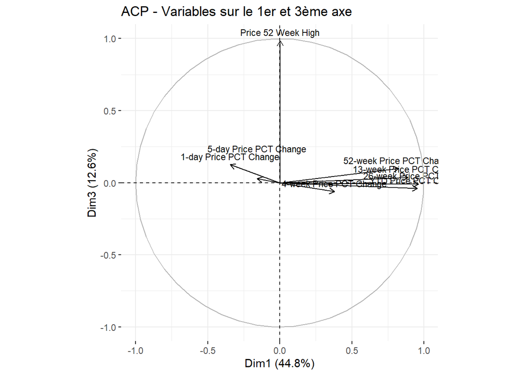

```r
fviz_pca_var(acp_eurostoxx, axes = c(1, 3),
             labelsize = 3) +
  labs(title = "ACP - Variables sur le 1er et 3ème axe")
```

Ce graphique représente le pourcentage de variance des variables expliqué par les différentes composantes dans notre analyse. Comme évoqué précédemment la première composante explique 44.8% de la variance, la deuxième 18.1%, et la troisième 12.6%.

Pour choisir le nombre d’axes avec lesquels travailler en ACP il existe de nombreuses méthodes dont les plus connues:

- La règle du coude: Celle-ci consiste à ne tenir compte que des dimensions avant qu’il y ait un point d’inflexion dans la variance expliquée. En l’occurrence ici, la règle du coude nous encouragerait à ne tenir compte que de la première composante.
- La règle des 75%: Cette règle nous dit qu’il faut conserver toutes les dimensions jusqu’à avoir 75% de variance cumulée. Dans notre cas cela voudrait dire qu’on conserverait les 3 premiers axes dans notre analyse.

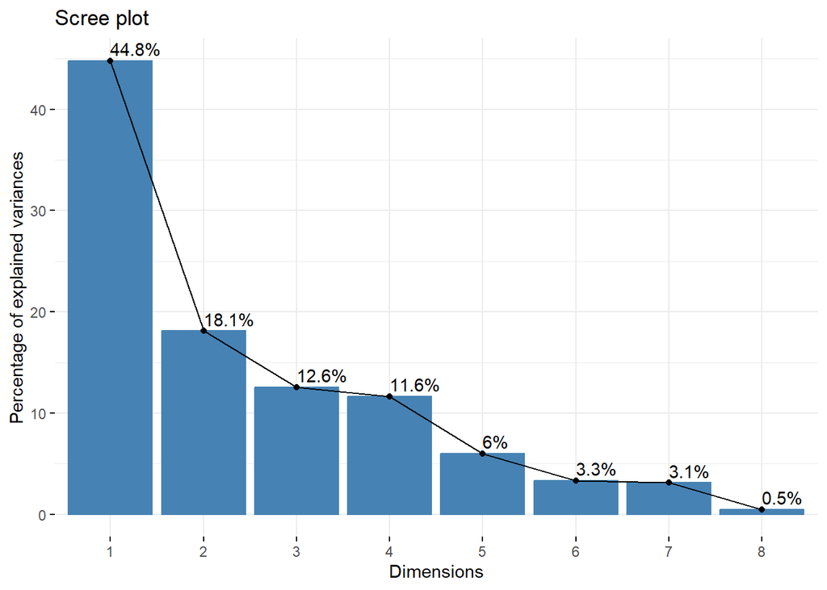

```r
fviz_eig(acp_eurostoxx, addlabels=T)
```

Extraction de la variable financière Fi à partir de la première composante

```r
Fi <- acp_eurostoxx$ind$coord[, "Dim.1"]
```

# PARTIE 3: Statistiques descriptives et régression linéaire (Question 3)

On va tout d’abord contruire un nouveau dataframe à partir des variables dont on a besoin pour faire notre analyse qui ont été évoquées dans l’énoncé.

```r
names(eurostoxx) <- gsub("\n", " ", names(eurostoxx))

# Now subset with the modified column names
new_eurostoxx <- eurostoxx[, c("COUNTRY OF DOMICIL",
                        "Environment Pillar Score",
                        "EMPLOYEES",
                        "OPERATING PROFIT MARGIN",
                        "NET SALES OR REVENUES",
                        "Market Cap\r (Σ=Avg)",
                        "RETURN ON INVESTED CAPITAL",
                        "CSR Sustainability Committee",
                        "Value - Board Structure/Independent Board Members")]
```

```r
new_eurostoxx$Fi <- Fi
```

Tout d’abord, on va voir les différentes classes dans notre base de données. On constate que les variables auxquelles on va s’intéresser pour notre études sont de différents types:

**-Environment Pillar Score (EPS): charactère**

COUNTRY OF DOMICIL: chaine de caractères

-EMPLOYEES (EMP): chaine de caractères

-OPERATING PROFIT MARGIN (MARGIN): chaine de caractères -> à modifier

-NET SALES OR REVENUES (SALES): caractère -> à modifier

-Market Cap (MCAP): numérique

-RETURN ON INVESTED CAPITAL (RCAP): charactère -> à modifier

-Value: Board Structure/Independent Board Members (Board) –> caractère

Pour cette étude, on va tenter d’expliquer la variable Environment Pillar Score (EPS) à travers toutes les variables explicatives

```r
lapply(new_eurostoxx, class)
```

```
## $`COUNTRY OF DOMICIL`
## [1] "character"
##
## $`Environment Pillar Score`
## [1] "character"
##
## $EMPLOYEES
## [1] "character"
##
## $`OPERATING PROFIT MARGIN`
## [1] "character"
##
## $`NET SALES OR REVENUES`
## [1] "character"
##
## $`Market Cap\r (Σ=Avg)`
## [1] "numeric"
##
## $`RETURN ON INVESTED CAPITAL`
## [1] "character"
##
## $`CSR Sustainability Committee`
## [1] "character"
##
## $`Value - Board Structure/Independent Board Members`
## [1] "character"
##
## $Fi
## [1] "numeric"
```

Avant de procéder à une analyse plus détaillée sur nos variables, on doit d’abord convertir les variables charactères en tant que variables numérique afin de pouvoir les visualiser et effectuer les analyses nécessaires dessus.

```r
variables <- c("Environment Pillar Score", "EMPLOYEES", "OPERATING PROFIT MARGIN", "NET SALES OR REVENUES","RETURN ON INVESTED CAPITAL","Value - Board Structure/Independent Board Members")

new_eurostoxx[variables] <- lapply(new_eurostoxx[variables], as.numeric)
```

```r
lapply(new_eurostoxx, class)
```

```
## $`COUNTRY OF DOMICIL`
## [1] "character"
##
## $`Environment Pillar Score`
## [1] "numeric"
##
## $EMPLOYEES
## [1] "numeric"
##
## $`OPERATING PROFIT MARGIN`
## [1] "numeric"
##
## $`NET SALES OR REVENUES`
## [1] "numeric"
##
## $`Market Cap\r (Σ=Avg)`
## [1] "numeric"
##
## $`RETURN ON INVESTED CAPITAL`
## [1] "numeric"
##
## $`CSR Sustainability Committee`
## [1] "character"
##
## $`Value - Board Structure/Independent Board Members`
## [1] "numeric"
##
## $Fi
## [1] "numeric"
```

Une autre transformation qui doit également être effectuée est sur notre variable catégorique ’CSR Sustainability Committee” qui porte pour valeur Y et N correspondant au fait si oui ou non une entreprise possède une comité CSR dans sa structure. Pour pouvoir traiter cette variable, on doit la transfomer en facteur.

```r
#On vérifie si la colonne CSR sustainability est en facteur
is.factor(new_eurostoxx$'CSR Sustainability Committee')
```

```
## [1] FALSE
```

```r
#On tranforme le type de la colonne
new_eurostoxx$'CSR Sustainability Committee' <- factor(
  new_eurostoxx$'CSR Sustainability Committee',
  levels = c("Y", "N"),
  label= c("Oui", "Non"))
#On vérifie si la colonne prend désormais le type facteur
is.factor(new_eurostoxx$`CSR Sustainability Committee`)
```

```
## [1] TRUE
```

On fait la même chose sur la variable COUNTRY OF DOMICIL qui est une variable catégorique qui correspond au pays d’origine de chaque entreprise.

```r
unique(new_eurostoxx$`COUNTRY OF DOMICIL`)
```

```
##  [1] "BD" "BG" "BM" "DK" "ES" "FN" "FR" "IR" "IT" "LX" "MA" NA   "NL" "NW" "OE"
## [16] "PT" "SD" "SW" "UK" "FA" "IM" "PO"
```

```r
is.factor(new_eurostoxx$`COUNTRY OF DOMICIL`)
```

```
## [1] FALSE
```

```r
new_eurostoxx$`COUNTRY OF DOMICIL` <- factor(
  new_eurostoxx$`COUNTRY OF DOMICIL`,
  levels = c("BD", "BG", "BM", "DK", "ES", "FN", "FR", "IR",
             "IT", "LX", "MA", "NL", "NW", "OE", "PT",
             "SD", "SW", "UK", "FA", "IM", "PO"),
  labels = c("Allemagne", "Bulgarie", "Bermudes", "Danemark",
             "Espagne", "Finlande", "France", "Irlande",
             "Italie", "Luxembourg", "Malte",
             "Pays-Bas", "Norvège", "Autriche", "Portugal",
             "Suède", "Suisse", "Royaume-Uni", "Îles Féroé",
             "Île de Man", "Pologne")
)

is.factor(new_eurostoxx$`COUNTRY OF DOMICIL`)
```

```
## [1] TRUE
```

```r
#Afficher tous les levels
levels(new_eurostoxx$`COUNTRY OF DOMICIL`)
```

```
##  [1] "Allemagne"   "Bulgarie"    "Bermudes"    "Danemark"    "Espagne"
##  [6] "Finlande"    "France"      "Irlande"     "Italie"      "Luxembourg"
## [11] "Malte"       "Pays-Bas"    "Norvège"     "Autriche"    "Portugal"
## [16] "Suède"       "Suisse"      "Royaume-Uni" "Îles Féroé"  "Île de Man"
## [21] "Pologne"
```

Puisque le nom des pays est donné par code, on fait une recherche sur ce que chaque code de pays signifie et on lui donne sa valeur réelle en tant que label en utilisant la commande factor().

## A. Traiter les valeurs manquantes

Lorsqu’on a des données manquantes, il peut être tentant de simplement les ignorer et de travailler et contruire notre modèle avec des données manquantes. Sachant que chaque obervation nous permet de gagner en précision, construire un modèle avec des données manquantes peut nous faire perdre en précision. Pour savoir que faire avec nos données manquantes, il est important de d’en connaître la raison. C’est pour cela que dans cette partie, on va essayer d’analyser la structure de nos données manquantes pour savoir de quelle façon on peut y remédier.

```r
#On renomme la colonne return on invested capital pour avoir plus d'espace
names(new_eurostoxx)[names(new_eurostoxx) == "RETURN ON INVESTED CAPITAL"] <- "ROIC"
names(new_eurostoxx)[names(new_eurostoxx) == "Market Cap\r (Σ=Avg)"] <- "Market Cap"
#On utilise la fonction pander ici car elle nous permet d'avoir un summary plus compréhensible et simple à lire.
pander(summary(new_eurostoxx))
```

Table continues below

| COUNTRY OF DOMICIL | Environment Pillar Score | EMPLOYEES |
| --- | --- | --- |
| Royaume-Uni:131 | Min. : 0.00 | Min. : 0 |
| France : 69 | 1st Qu.:49.15 | 1st Qu.: 3851 |
| Allemagne : 65 | Median :69.01 | Median : 14522 |
| Suède : 61 | Mean :63.95 | Mean : 40720 |
| Suisse : 53 | 3rd Qu.:82.92 | 3rd Qu.: 43495 |
| (Other) :195 | Max. :98.16 | Max. :671205 |
| NA’s : 26 | NA’s :46 | NA’s :28 |

Table continues below

| OPERATING PROFIT MARGIN | NET SALES OR REVENUES | Market Cap |
| --- | --- | --- |
| Min. :-275.78 | Min. : 52061 | Min. :1.480e+09 |
| 1st Qu.: 7.28 | 1st Qu.: 2385684 | 1st Qu.:5.548e+09 |
| Median : 12.86 | Median : 7159000 | Median :1.386e+10 |
| Mean : 20.04 | Mean : 23724980 | Mean :4.050e+10 |
| 3rd Qu.: 23.02 | 3rd Qu.: 23969000 | 3rd Qu.:3.639e+10 |
| Max. : 731.44 | Max. :554184257 | Max. :1.322e+12 |
| NA’s :28 | NA’s :27 | NA |

Table continues below

| ROIC | CSR Sustainability Committee | Value - Board Structure/Independent Board Members |
| --- | --- | --- |
| Min. :-50.960 | Oui :447 | Min. : 0.00 |
| 1st Qu.: 4.610 | Non :107 | 1st Qu.: 50.00 |
| Median : 8.175 | NA’s: 46 | Median : 65.00 |
| Mean : 10.837 | NA | Mean : 64.15 |
| 3rd Qu.: 13.688 | NA | 3rd Qu.: 80.00 |
| Max. :437.740 | NA | Max. :100.00 |
| NA’s :30 | NA | NA’s :46 |

| Fi |
| --- |
| Min. :-5.57855 |
| 1st Qu.:-1.20906 |
| Median :-0.05844 |
| Mean : 0.00000 |
| 3rd Qu.: 1.02492 |
| Max. :11.21337 |
| NA |

Dans notre jeu de données on a identifié dans la première partie de notre analyse qu’on avait beaucoup de données manquantes. Etant de données que dans notre jeu de données ne contient pas un grand nombre d’observations, on essaye d’analyser ces valeurs manquantes pour voir si il y a une structure particulière qui affecte les valeurs manquantes et on essaye de les remplacer afin de ne pas avoir un grande perte d’information pour estimer notre modèle de façon plus précise.

```r
#les packages nécessaire pour faire l'analyse des valeurs manquantes
library(tidyverse)
library(naniar)
library(gtExtras)
library(mice)
```

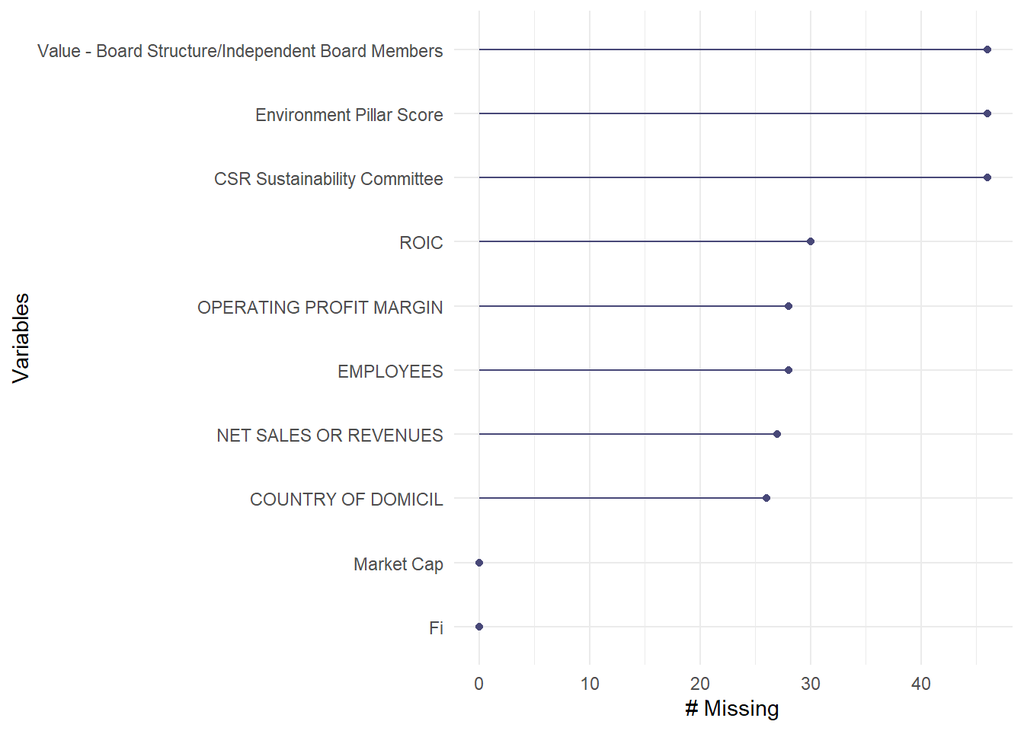

```r
gg_miss_var(new_eurostoxx)
```

- La supression des valeurs manquantes
- Le remplacement par une stastique comme la médiane ou la moyenne
- L’estimation à travers un modèle machine learning comme KNN (k-nearest neighbor) qui consiste à calculer une moyenne de l’observation manquante avec ses voisins les plus proche

Dans notre cas, on a des données qui sont manquantes sur les mêmes observations simultanément et donc les remplacer par une valeur ‘artificielle’ pourrait nuire à la précision du modèle qu’on cherche à construire et à estimer. Pour cela, on fait le choix de supprimer les observations là ou il y ‘a des observations manquantes sur plus de 3 colonnes, et on remplacera par la médiane une observation qui est uniquement manquante sur la colonne ’operating profit margin’.

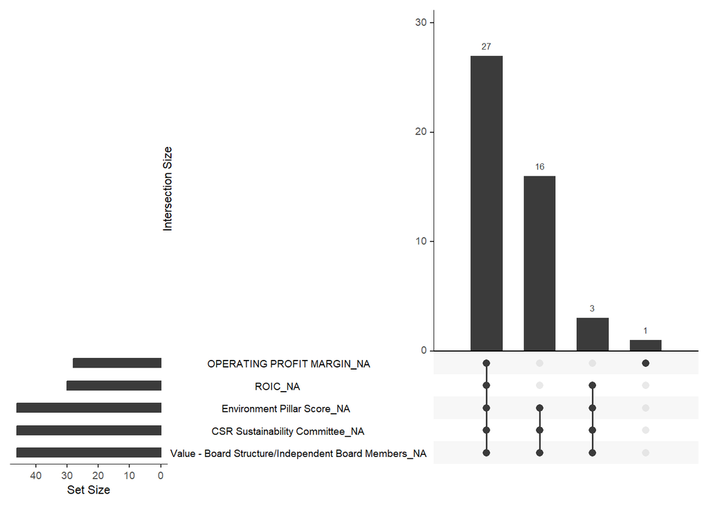

```r
gg_miss_upset(new_eurostoxx)
```

Etant donné que la variable qu’on cherche à expliquer est le score environnemental, on remarque que sur plusieurs observations, on a des valeurs manquantes sur cette colonne qui sont aussi manquantes sur d’autres colonnes avec lesquelles on cherche à expliquer la variation dans le score environnemental. Pour y remédier, on supprime ces observations la car les remplacer par la médiane ou la moyenne sur plusieurs colonnes et donc les remplacer par des valeurs artificielles pourrait induire à un biais dans le modèle qu’on cherche à construire plus tard.

```r
#On reconstruit donc notre data frame sans inclure les observations sur lesquelles on a des valeurs manquantes sur 5 colonnes au même temps
new_eurostoxx <- new_eurostoxx[!(
  is.na(new_eurostoxx$`OPERATING PROFIT MARGIN`) &
  is.na(new_eurostoxx$ROIC) &
  is.na(new_eurostoxx$`Environment Pillar Score`) &
  is.na(new_eurostoxx$`CSR Sustainability Committee`) &
  is.na(new_eurostoxx$`Value - Board Structure/Independent Board Members`)
), ]
```

Ici on reconstruit notre data frame en excluant les observations sur lesquelles on a des valeurs manquantes sur plus de 4 colonnes au même temps pour les mêmes observations.

```r
new_eurostoxx <- new_eurostoxx[!(
  is.na(new_eurostoxx$ROIC) &
  is.na(new_eurostoxx$`Environment Pillar Score`) &
  is.na(new_eurostoxx$`CSR Sustainability Committee`) &
  is.na(new_eurostoxx$`Value - Board Structure/Independent Board Members`)
), ]
```

Ici on reconstruit notre data frame en excluant les observations sur lesquelles on a des valeurs manquantes sur plus de 3 colonnes au même temps pour les mêmes observations.

```r
new_eurostoxx <- new_eurostoxx[!(
  is.na(new_eurostoxx$`Environment Pillar Score`) &
  is.na(new_eurostoxx$`CSR Sustainability Committee`) &
  is.na(new_eurostoxx$`Value - Board Structure/Independent Board Members`)
), ]
```

Grâce aux transformation qu’on a faites, il ne nous reste plus que des valeurs manquantes sur la colonne ‘Operating profit’. Etant donné qu’il ne s’agit que d’une seule valeur, on va la remplacer par sa médiane de sorte à ne plus avoir de valeurs manquantes dans notre jeu de données.

En utilisant la commande structure pour voir notre jeu de données, on voit bien qu’après les opérations qu’on a faite qu’il ne nous reste plus qu’une seule valeur manquante sur la colonne ‘Operating Profit’.

```r
pander(summary (new_eurostoxx))
```

Table continues below

| COUNTRY OF DOMICIL | Environment Pillar Score | EMPLOYEES |
| --- | --- | --- |
| Royaume-Uni:125 | Min. : 0.00 | Min. : 0 |
| France : 69 | 1st Qu.:49.15 | 1st Qu.: 4267 |
| Allemagne : 63 | Median :69.01 | Median : 14682 |
| Suède : 57 | Mean :63.95 | Mean : 41524 |
| Suisse : 53 | 3rd Qu.:82.92 | 3rd Qu.: 45898 |
| Pays-Bas : 28 | Max. :98.16 | Max. :671205 |
| (Other) :159 | NA | NA |

Table continues below

| OPERATING PROFIT MARGIN | NET SALES OR REVENUES | Market Cap |
| --- | --- | --- |
| Min. :-275.78 | Min. : 69783 | Min. :1.480e+09 |
| 1st Qu.: 7.47 | 1st Qu.: 2540608 | 1st Qu.:5.555e+09 |
| Median : 12.93 | Median : 7342750 | Median :1.366e+10 |
| Mean : 20.67 | Mean : 23830453 | Mean :4.131e+10 |
| 3rd Qu.: 23.05 | 3rd Qu.: 24053000 | 3rd Qu.:3.673e+10 |
| Max. : 731.44 | Max. :554184257 | Max. :1.322e+12 |
| NA’s :1 | NA | NA |

Table continues below

| ROIC | CSR Sustainability Committee | Value - Board Structure/Independent Board Members |
| --- | --- | --- |
| Min. :-38.140 | Oui:447 | Min. : 0.00 |
| 1st Qu.: 4.622 | Non:107 | 1st Qu.: 50.00 |
| Median : 8.230 | NA | Median : 65.00 |
| Mean : 11.013 | NA | Mean : 64.15 |
| 3rd Qu.: 13.750 | NA | 3rd Qu.: 80.00 |
| Max. :437.740 | NA | Max. :100.00 |
| NA | NA | NA |

| Fi |
| --- |
| Min. :-5.57855 |
| 1st Qu.:-1.12188 |
| Median :-0.02788 |
| Mean : 0.04263 |
| 3rd Qu.: 1.00856 |
| Max. :11.21337 |
| NA |

On remplace la valeur manquante sur la colonne operating profit margin par la médiane et on voit bien qu’après traitement de notre jeu de données pour les valeurs manquantes, il ne nous reste plus de valeurs ‘NA’ dans nos colonnes. L’opération a donc bien fonctionné et le nombre d’observations dans notre jeu de données passe de 600 à 554, ce qui nous reste tout de même très suffisant pour estimer un modèle non biaisé. Dans le cas ou on aurait eu un bien plus grand nombre de NA, on aurait considérer d’autres approches de remplacement robustes en utilisant des méthodes de remplacement par modèle de machine learning pour tenter de préserver au maximum le nombre d’observations. Etant donné que 554 observations sont très suffisantes pour constuire un modèle de regression, on a donc fait le choix de supprimer des observations pour les lignes qui posaient problème et de remplacer par la médiane.

```r
mediane <- median (new_eurostoxx$`OPERATING PROFIT MARGIN`, na.rm = TRUE)
new_eurostoxx$`OPERATING PROFIT MARGIN`[is.na(new_eurostoxx$`OPERATING PROFIT MARGIN`)] <- mediane
pander(summary(new_eurostoxx))
```

Table continues below

| COUNTRY OF DOMICIL | Environment Pillar Score | EMPLOYEES |
| --- | --- | --- |
| Royaume-Uni:125 | Min. : 0.00 | Min. : 0 |
| France : 69 | 1st Qu.:49.15 | 1st Qu.: 4267 |
| Allemagne : 63 | Median :69.01 | Median : 14682 |
| Suède : 57 | Mean :63.95 | Mean : 41524 |
| Suisse : 53 | 3rd Qu.:82.92 | 3rd Qu.: 45898 |
| Pays-Bas : 28 | Max. :98.16 | Max. :671205 |
| (Other) :159 | NA | NA |

Table continues below

| OPERATING PROFIT MARGIN | NET SALES OR REVENUES | Market Cap |
| --- | --- | --- |
| Min. :-275.780 | Min. : 69783 | Min. :1.480e+09 |
| 1st Qu.: 7.478 | 1st Qu.: 2540608 | 1st Qu.:5.555e+09 |
| Median : 12.930 | Median : 7342750 | Median :1.366e+10 |
| Mean : 20.658 | Mean : 23830453 | Mean :4.131e+10 |
| 3rd Qu.: 23.047 | 3rd Qu.: 24053000 | 3rd Qu.:3.673e+10 |
| Max. : 731.440 | Max. :554184257 | Max. :1.322e+12 |
| NA | NA | NA |

Table continues below

| ROIC | CSR Sustainability Committee | Value - Board Structure/Independent Board Members |
| --- | --- | --- |
| Min. :-38.140 | Oui:447 | Min. : 0.00 |
| 1st Qu.: 4.622 | Non:107 | 1st Qu.: 50.00 |
| Median : 8.230 | NA | Median : 65.00 |
| Mean : 11.013 | NA | Mean : 64.15 |
| 3rd Qu.: 13.750 | NA | 3rd Qu.: 80.00 |
| Max. :437.740 | NA | Max. :100.00 |
| NA | NA | NA |

| Fi |
| --- |
| Min. :-5.57855 |
| 1st Qu.:-1.12188 |
| Median :-0.02788 |
| Mean : 0.04263 |
| 3rd Qu.: 1.00856 |
| Max. :11.21337 |
| NA |

## B. Détecter et traiter les valeurs aberrantes (question 3)

Maintenant que nous n’avons plus de valeurs manquantes sur notre jeu de données, on passe à la détection et au traitement des valeurs aberrantes qui peuvent exister sur notre jeu de données.

Les valeurs aberrantes sont des valeurs qui diffèrent significativement des autres observations sur notre jeu de données. Elles peuvent être soit beaucoup plus grandes ou beaucoup plus petites que les autres observations avec lequelles on travaille. Elle sont particulièrement problèmatiques dans notre cas, car le modèle qu’on cherche à construire est une régression liénaire. Dans la régression linéaire on utilise la méthode des moindres carrés pour estimer nos coefficients. Les valeurs aberrantes peuvent donc avoir une influence disprportionnée sur cette somme de carrés en tirant la ligne de régression vers elles, ce qui fausserait les coefficients estimés et pourrait nous induire en erreur en concluant qu’un coefficient est significatif lorsqu’il ne l’ai pas, ou qu’il ai non significatif lorsqu’il l’est. Nous devons donc détecter l’existence de ces valeurs aberrantes et trouver un moyen de les traiter pour s’assurer d’estimer les relations entre nos variables sans biais.

La formule qu’on utilise en général pour détecter la présence de valeurs aberrantes est la suivante:

**[𝑄1−1.5×𝐼𝑄𝑅,𝑄3+1.5×𝐼𝑄𝑅]** avec Q1 étant le premier quartile et Q3 étant le troisième quartile.

On peut également détecter la présence de valeurs aberrantes grâce au graphique en boite (le box plot), ou les valeurs aberrantes s’affichent généralement distancées du premier et deuxième quartile. On va voir que dans certaines cas extrêmes, le box plot s’affiche comme étant totalement distordu et ça nous permet de détecter la présence de valeurs aberrantes extrêmes.

Pour notre analyse, on va analyser chacune de nos variables une par une en commençant par la variable endogène du score environnemental.

Ici, pour la valeur qu’on cherche à estimer du score environnemental, on remarque qu’il n’y a pas de valeurs aberrantes et on affiche ces principales stastiques grâce à la commande summary.

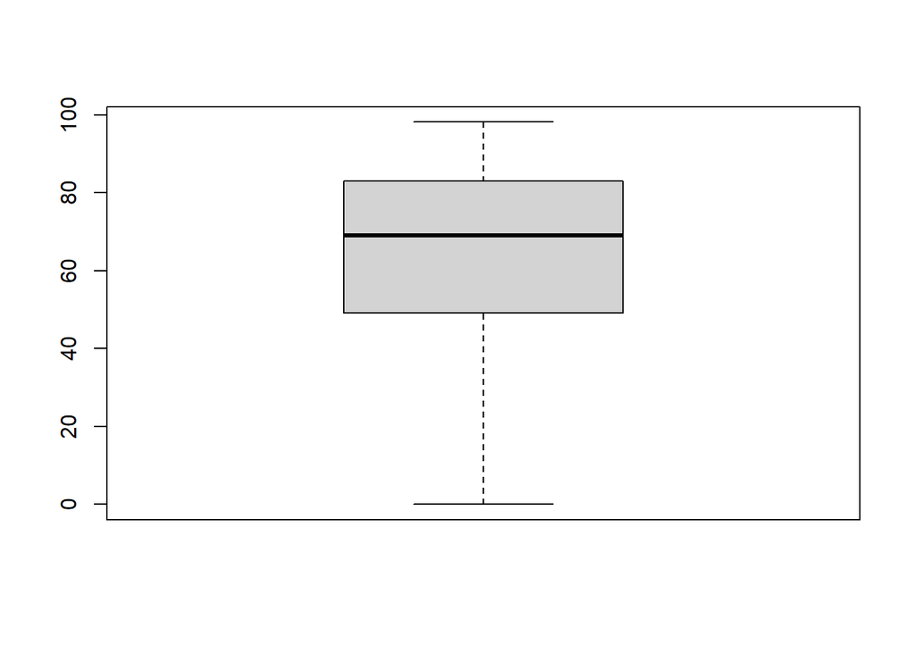

```r
boxplot(new_eurostoxx$`Environment Pillar Score`)
```

```r
summary(new_eurostoxx$`Environment Pillar Score`)
```

```
##    Min. 1st Qu.  Median    Mean 3rd Qu.    Max.
##    0.00   49.15   69.01   63.95   82.92   98.16
```

On va effectuer de même avec toutes les autres variables qu’on va inclure dans notre modèle.

### La variable employés

Pour la variable qui représente le nombre d’employés, on remarque qu’il y a une très grande présence de valeurs aberrantes. On a beaucoup de valeurs qui sont réparties vers le haut du graphique et le diagramme est complètement déformé.

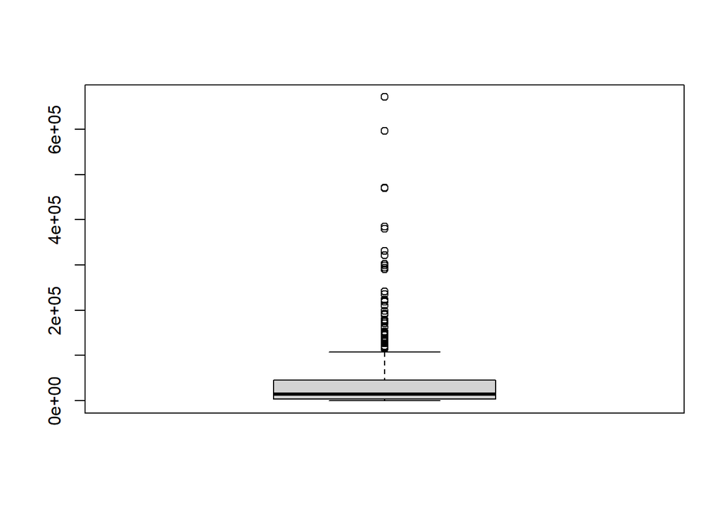

```r
boxplot(new_eurostoxx$`EMPLOYEES`)
```

```r
summary(new_eurostoxx$`EMPLOYEES`)
```

```
##    Min. 1st Qu.  Median    Mean 3rd Qu.    Max.
##       0    4267   14682   41524   45898  671205
```

Maintenant que nous avons identifié graphiquement la présence de valeurs aberrantes sur la colonne qui correspond au nombre d’employés, on identifie ces valeurs aberrantes et on les mets dans la variable ‘Valeurs_aberrantes_employees’. On calcule également le pourcentage de valeurs aberrantes dans notre colonne. Sur la colonne employés, on a plus de 9% des observations qui sont aberrantes, ce qui est énorme.

```r
# Calculer les quartiles et la différence entre les quartiles
Q1 <- quantile(new_eurostoxx$EMPLOYEES, 0.25, na.rm = TRUE)
Q3 <- quantile(new_eurostoxx$EMPLOYEES, 0.75, na.rm = TRUE)
IQR <- Q3 - Q1

# Définir les limites inférieures et supérieures
limite_inférieure <- Q1 - 1.5 * IQR
limite_supérieure <- Q3 + 1.5 * IQR

# Identifier les valeurs aberrantes
Valeurs_aberrantes_employees <- new_eurostoxx$EMPLOYEES[new_eurostoxx$EMPLOYEES < limite_inférieure | new_eurostoxx$EMPLOYEES > limite_supérieure]
print(Valeurs_aberrantes_employees)
```

```
##  [1] 133778 241458 210533 385000 162372 138353 147268 117628 175000 471056
## [11] 126973 192376 174386 117347 321383 223370 133197 147715 470237 127200
## [21] 151297 178780 170643 219314 222397 138240 198816 179565 135619 171000
## [31] 114700 191000 380000 115428 126376 302055 144400 291000 235351 138097
## [41] 116400 153000 596452 294134 120659 671205 298655 190431 130621 331065
## [51] 151242 163309 118523 134931 321490
```

```r
print(length(Valeurs_aberrantes_employees)/length(new_eurostoxx$EMPLOYEES))
```

```
## [1] 0.09927798
```

```r
#Près de 10% des valeurs dans la colonnes employees sont des valeurs aberrantes
```

### Variable Operating Profit margin

On fait la même chose avec la variable Operating Profit Margin et on a également un box plot qui s’affiche totalement déformé ce qui indique qui forte présence de valeurs aberrantes.

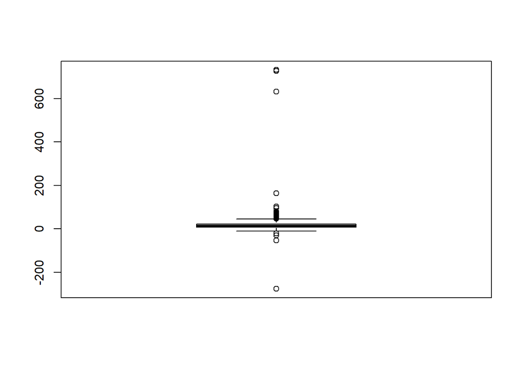

```r
boxplot(new_eurostoxx$`OPERATING PROFIT MARGIN`)
```

```r
summary(new_eurostoxx$`OPERATING PROFIT MARGIN`)
```

```
##     Min.  1st Qu.   Median     Mean  3rd Qu.     Max.
## -275.780    7.478   12.930   20.658   23.047  731.440
```

On fait la même chose qu’on a fait pour employees en créant un vecteur pour les valeurs aberrantes de ‘Operating profit margin’.

```r
# Calculer les quartiles et la différence entre les quartiles
Q1 <- quantile(new_eurostoxx$`OPERATING PROFIT MARGIN`, 0.25, na.rm = TRUE)
Q3 <- quantile(new_eurostoxx$`OPERATING PROFIT MARGIN`, 0.75, na.rm = TRUE)
IQR <- Q3 - Q1

# Définir les limites inférieures et supérieures
limite_inférieure <- Q1 - 1.5 * IQR
limite_supérieure <- Q3 + 1.5 * IQR

# Identifier les valeurs aberrantes
Valeurs_aberrantes_OPM <- new_eurostoxx$`OPERATING PROFIT MARGIN`[new_eurostoxx$`OPERATING PROFIT MARGIN` < limite_inférieure| new_eurostoxx$`OPERATING PROFIT MARGIN` > limite_supérieure]
print(Valeurs_aberrantes_OPM)
```

```
##  [1]  -20.79   48.14   53.57   57.14   60.69   57.22   48.31  731.44   54.01
## [10]   49.87   79.66   55.71   53.09   62.66  102.49   68.35   53.47  -53.60
## [19]   95.93   70.84  631.69   75.91   75.02   52.42   49.16   51.65   57.14
## [28]   49.18  -30.66 -275.78   49.03  164.31   57.79   60.06  726.99   54.59
## [37]   66.21   63.95   73.87   53.01   51.98   58.84
```

```r
print(length(Valeurs_aberrantes_OPM)/length(new_eurostoxx$`OPERATING PROFIT MARGIN`))
```

```
## [1] 0.07581227
```

```r
#On constate que 7% des valeurs sur la colonnes operating profit margin sont des valeurs aberrantes
```